# Virginia Election Analysis

Author

Zoe Bourne

#### Overview

Throughout the following page, we will be exploring and analyzing the Virginia election results of Mcauliffe versus Youngkin. We will then be comparing the results of the governors race to the presidential race between Biden and Trump.

#### Code

```r
#the 'head' function allows us to see our data table for the datat joined_vacomparison
head(joined_vacomparison)
```

```
# A tibble: 6 × 9
  locality         biden trump biden_pct trump…¹ young…² mcaul…³ pct_y…⁴ pct_m…⁵
  <chr>            <dbl> <dbl>     <dbl>   <dbl>   <int>   <int>   <dbl>   <dbl>
1 ACCOMACK COUNTY   7578  9172      44.7    54.1    7878    4948    61.1    38.4
2 ALBEMARLE COUNTY 42466 20804      65.7    32.2   19141   31919    37.2    62.0
3 ALEXANDRIA CITY  66240 14544      80.3    17.6   14013   43866    24.0    75.2
4 ALLEGHANY COUNTY  2243  5859      27.3    71.4    4530    1518    74.5    25.0
5 AMELIA COUNTY     2411  5390      30.6    68.3    4720    1617    74.2    25.4
6 AMHERST COUNTY    5672 11041      33.4    64.9    9731    3897    71      28.4
# … with abbreviated variable names ¹trump_pct, ²youngkin, ³mcauliffe,
#   ⁴pct_youngkin, ⁵pct_mcauliffe
```

```r
#the following information will be saved as updated_joined_vacomparison, editing joined_vacomparison
updated_joined_vacomparison <- joined_vacomparison%>%
mutate(
      #create new column of the difference between democratic candiated, subracting the presidential canidate from the candiate for governor
  compare_dem = pct_mcauliffe - biden_pct,
      #create new column of the difference between republican candiated, subracting the presidential canidate from the candiate for governor
  compare_rep = pct_youngkin - trump_pct,
      #create new column of the difference between the two candiated for governor, subracting Youngkin from Mcauliffe
  compare_gov = pct_mcauliffe - pct_youngkin,
      #create new column of the difference between the two candiated for presindent, subracting Biden from Trump
   compare_pres = biden_pct - trump_pct
)
```

#### Table One - What Virginia Counties Did Mcauliffe Receive the Largest Percentage of Votes?

```r
#the following information will be saved as dem_table, editing updated_joined_vacomparison
dem_table <- updated_joined_vacomparison%>%
  #the data set will be arranged in descending order based on the variable pct_mcauliffe (the percent of votes received by Mcauliffe)
  arrange(desc(pct_mcauliffe))%>%
  #head specifies that we want the new data set to include the top five counties where Mcauliffe received the largest percentage of votes
  head(5)

#the following data for the chart comes from the data set 'dem_table'
dem_table%>%
#the variables chosen to be highlighted in this table are the following - locality, pct_mcauliffe, pct_youngkin, trump_pct, biden_pct, compare_dem, compare_rep
select(locality, pct_mcauliffe, pct_youngkin, trump_pct, biden_pct, compare_dem, compare_rep) %>%
  #we will create a data table
  DT::datatable(
    #rownames false removes the column of row names from the data set
    rownames = FALSE,
    #options allows us to further customize the data table
                options = list(
                  #this data table will not include a search bar
                  searching = FALSE,
                  #paging set as false puts all the data on one page
                  paging = FALSE,
                  #the DOM elements include the table (t), table information summary (i), and pagination control (p)
                  dom = "tip"))
```

| locality | pct_mcauliffe | pct_youngkin | trump_pct | biden_pct | compare_dem | compare_rep |
| --- | --- | --- | --- | --- | --- | --- |
| PETERSBURG CITY | 84.87 | 13.5 | 11.22 | 87.75 | -2.88000000000001 | 2.28 |
| CHARLOTTESVILLE CITY | 82.88 | 15.99 | 12.78 | 85.5 | -2.62 | 3.21 |
| RICHMOND CITY | 77.27 | 19.61 | 14.94 | 82.92 | -5.65000000000001 | 4.67 |
| FALLS CHURCH CITY | 76.69 | 22.63 | 16.9 | 81.03 | -4.34 | 5.73 |
| ARLINGTON COUNTY | 76.67 | 22.63 | 17.08 | 80.6 | -3.93000000000001 | 5.55 |

#### Table Two - Percents and Comparisons of Virginia Governor Race and Presidential Race

```r
#the following data for the chart comes from the data set 'updated_joined_vacomparison'
updated_joined_vacomparison%>%
#the variables chosen to be highlighted in this table are the following - locality, compare_pres, compare_gov, compare_dem, compare_rep, pct_youngkin, pct_mcauliffe, trump_pct, biden_pct
select(locality, compare_pres, compare_gov, compare_dem, compare_rep, pct_youngkin, pct_mcauliffe, trump_pct, biden_pct) %>%
  #we will create a data table
  DT::datatable(
    #rownames false removes the column of row names from the data set
    rownames = FALSE,
               #options allows us to further customize the data table
                options = list(
                  #this data table will not include a search bar
                  searching = FALSE,
                  #paging set as fasle puts all the data on one page
                  paging = FALSE,
                  #the DOM elements include the table (t), table information summary (i), and pagination control (p)
                  dom = "tip"))
```

| locality | compare_pres | compare_gov | compare_dem | compare_rep | pct_youngkin | pct_mcauliffe | trump_pct | biden_pct |
| --- | --- | --- | --- | --- | --- | --- | --- | --- |
| ACCOMACK COUNTY | -9.39 | -22.71 | -6.31 | 7.01 | 61.08 | 38.37 | 54.07 | 44.68 |
| ALBEMARLE COUNTY | 33.5 | 24.84 | -3.63000000000001 | 5.03 | 37.21 | 62.05 | 32.18 | 65.68 |
| ALEXANDRIA CITY | 62.65 | 51.18 | -5.08 | 6.39 | 24.02 | 75.2 | 17.63 | 80.28 |
| ALLEGHANY COUNTY | -44.09 | -49.55 | -2.37 | 3.08999999999999 | 74.52 | 24.97 | 71.43 | 27.34 |
| AMELIA COUNTY | -37.74 | -48.77 | -5.13 | 5.89999999999999 | 74.19 | 25.42 | 68.29 | 30.55 |
| AMHERST COUNTY | -31.58 | -42.57 | -4.92 | 6.06999999999999 | 71 | 28.43 | 64.93 | 33.35 |
| APPOMATTOX COUNTY | -46.22 | -60.93 | -6.76 | 7.95 | 80.26 | 19.33 | 72.31 | 26.09 |
| ARLINGTON COUNTY | 63.52 | 54.04 | -3.93000000000001 | 5.55 | 22.63 | 76.67 | 17.08 | 80.6 |
| AUGUSTA COUNTY | -47.01 | -56.42 | -4.13 | 5.28 | 77.93 | 21.51 | 72.65 | 25.64 |
| BATH COUNTY | -47.5 | -58.7 | -5.49 | 5.71000000000001 | 79.04 | 20.34 | 73.33 | 25.83 |

[output cut: 123 more lines]

#### Chart One - In What Counties Did Youngkin Receive the Highest Percentage of Votes?

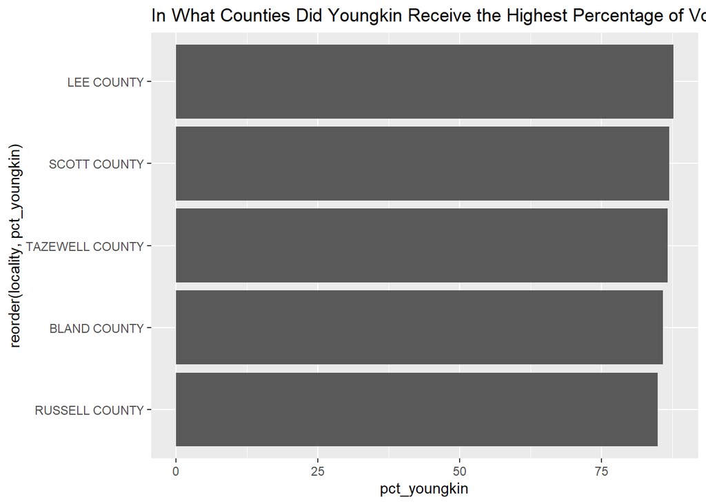

```r
#the following information will be saved as sorted_youngkin, editing updated_joined_vacomparison
sorted_youngkin <- updated_joined_vacomparison%>%
    #the data set will be arranged in descending order based on the variable pct_youngkin (the percent of votes received by Youngkin)
  arrange(desc(pct_youngkin))%>%
    #head specifies that we want the new data set to include the top five counties where Youngkin received the largest percentage of votes
  head(5)

#plot the data from the data set 'sorted_youngkin'
ggplot(sorted_youngkin,
        #the y axis will display counties, re-organized so the data will be displayed in descending order
       aes(y = reorder(locality, pct_youngkin),
           #the x axis measures the percentage of votes received by Youngkin
            x = pct_youngkin)) +
  #geom_col() indicates that the graph will be a bar chart
  geom_col() +
    # the title of the graph will be the following - In What Counties Did Youngkin Receive the Highest Percentage of Votes?
  labs(title = "In What Counties Did Youngkin Receive the Highest Percentage of Votes?")
```

#### Chart Two - Did Youngkin Perform Better Than Trump?

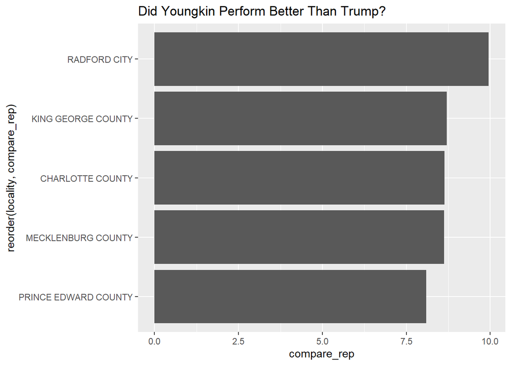

```r
#the following information will be saved as sorted_rep, editing updated_joined_vacomparison
sorted_rep <- updated_joined_vacomparison%>%
  #the data set will be arranged in descending order based on the varaible compare_rep (measuring the difference in votes received between the two republican canidates)
  arrange(desc(compare_rep))%>%
  #head specifies that we want the new data set to include the five counties with the largest difference in 'compare_rep'
  head(5)

#plot the data from the data set 'sorted_rep'
ggplot(sorted_rep,
       #the y axis will display counties, re-organized so the data will be displayed in descending order
       aes(y = reorder(locality, compare_rep),
           #the x axis measures the difference in points between the two candiates
           x = compare_rep)) +
  #geom_col() indicates that the graph will be a bar chart
  geom_col() +
  # the title of the graph will be the following - Did Youngkin Perform Better Than Trump?
  labs(title = "Did Youngkin Perform Better Than Trump?")
```

#### Analysis

##### Finding One

Exploring the relationship between the percent of votes received by the Virginia governors race and the presidential race, when looking at how both democratic candidates performed (Biden and Mcauliffe), there is a clear relationship between vote percentage and county. The five counties where Mcauliffe received the largest percentage of the votes is the same counties where Biden received the largest percentage of votes. These results can be seen in [Table One] in addition to the table below.

```r
#the following information will be saved as dem_table_two, editing updated_joined_vacomparison
dem_table_two <- updated_joined_vacomparison%>%
  #the data set will be arranged in descending order based on the variable pct_mcauliffe (the percent of votes received by Mcauliffe)
  arrange(desc(pct_mcauliffe))%>%
  #head specifies that we want the new data set to include the top five counties where Mcauliffe received the largest percentage of votes
  head(5)

#the following data for the chart comes from the data set 'updated_joined_vacomparison'
dem_table_two%>%
#the variables chosen to be highlighted in this table are the following - locality, pct_mcauliffe, biden_pct
select(locality, pct_mcauliffe, biden_pct) %>%
  #we will create a data table
  DT::datatable(
    #rownames false removes the column of row names from the data set
    rownames = FALSE,
               #options allows us to further customize the data table
                options = list(
                  #this data table will not include a search bar
                  searching = FALSE,
                  #paging set as fasle puts all the data on one page
                  paging = FALSE,
                  #the DOM elements include the table (t), table information summary (i), and pagination control (p)
                  dom = "tip"))
```

| locality | pct_mcauliffe | biden_pct |
| --- | --- | --- |
| PETERSBURG CITY | 84.87 | 87.75 |
| CHARLOTTESVILLE CITY | 82.88 | 85.5 |
| RICHMOND CITY | 77.27 | 82.92 |
| FALLS CHURCH CITY | 76.69 | 81.03 |
| ARLINGTON COUNTY | 76.67 | 80.6 |

##### Finding Two

When comparing how Trump performed in the counties where Youngkin received the highest percentage of votes, the top five counties for both candidates is less clear cut than for the democratic candidates. Both Trump and Younkin received the highest percentage of the vote in Lee County. However, the following four counties do not appear in the same ordere. Scott County, Tazewell County, and Bland County appear in one of the following four spots for both candidates, but in different spots on the list. These results can be seen in [Table Two] in addition to the table below.

```r
#the following information will be saved as rep_table_two, editing updated_joined_vacomparison
rep_table_two <- updated_joined_vacomparison%>%
  #the data set will be arranged in descending order based on the variable pct_youngkin (the percent of votes received by Youngkin)
  arrange(desc(pct_youngkin))%>%
  #head specifies that we want the new data set to include the top five counties where Youngkin received the largest percentage of votes
  head(5)

#the following data for the chart comes from the data set 'updated_joined_vacomparison'
rep_table_two%>%
#the variables chosen to be highlighted in this table are the following - locality, pct_youngkin, trump_pct
select(locality, pct_youngkin, trump_pct) %>%
  #we will create a data table
  DT::datatable(
    #rownames false removes the column of row names from the data set
    rownames = FALSE,
               #options allows us to further customize the data table
                options = list(
                  #this data table will not include a search bar
                  searching = FALSE,
                  #paging set as fasle puts all the data on one page
                  paging = FALSE,
                  #the DOM elements include the table (t), table information summary (i), and pagination control (p)
                  dom = "tip"))
```

| locality | pct_youngkin | trump_pct |
| --- | --- | --- |
| LEE COUNTY | 87.6 | 84.1 |
| SCOTT COUNTY | 86.89 | 83.38 |
| TAZEWELL COUNTY | 86.59 | 83.1 |
| BLAND COUNTY | 85.78 | 83.44 |
| RUSSELL COUNTY | 84.83 | 81.27 |

##### Finding Three

Comparing the performance of both democratic candidates in Virginia, Biden performed better than Mcauliffe in every county in Virginia. In other words, in every county in Virginia, Biden received a higher percentage of the votes when compared to Mcauliffe’s performance in that same county. These results can be seen in [Table Two] in addition to the table below.

```r
#the following data for the chart comes from the data set 'updated_joined_vacomparison'
updated_joined_vacomparison%>%
#the variables chosen to be highlighted in this table are the following - locality, compare_dem, pct_mcauliffe, biden_pct
select(locality, compare_dem, pct_mcauliffe, biden_pct) %>%
  #we will create a data table
  DT::datatable(
    #rownames false removes the column of row names from the data set
    rownames = FALSE,
               #options allows us to further customize the data table
                options = list(
                  #this data table will not include a search bar
                  searching = FALSE,
                  #paging set as fasle puts all the data on one page
                  paging = FALSE,
                  #the DOM elements include the table (t), table information summary (i), and pagination control (p)
                  dom = "tip"))
```

| locality | compare_dem | pct_mcauliffe | biden_pct |
| --- | --- | --- | --- |
| ACCOMACK COUNTY | -6.31 | 38.37 | 44.68 |
| ALBEMARLE COUNTY | -3.63000000000001 | 62.05 | 65.68 |
| ALEXANDRIA CITY | -5.08 | 75.2 | 80.28 |
| ALLEGHANY COUNTY | -2.37 | 24.97 | 27.34 |
| AMELIA COUNTY | -5.13 | 25.42 | 30.55 |
| AMHERST COUNTY | -4.92 | 28.43 | 33.35 |
| APPOMATTOX COUNTY | -6.76 | 19.33 | 26.09 |
| ARLINGTON COUNTY | -3.93000000000001 | 76.67 | 80.6 |
| AUGUSTA COUNTY | -4.13 | 21.51 | 25.64 |
| BATH COUNTY | -5.49 | 20.34 | 25.83 |

[output cut: 123 more lines]